# Titanic Survivor Case Study

A Comparison of Cross Validation Parameters

Mike Silva

April 2015

# Introduction

In this study we compare random forest models built in R using the caret package that predict the likelihood of emerging as a Titanic survivor. Different cross validation parameters will be used to create six models. We then compare the models in terms of accuracy and execution time.

## Data Used in This Study

The survivor data used in this analyis is found in [Carnegie Mellon University Department of Statitics’s StatLib](http://lib.stat.cmu.edu/S/Harrell/data/descriptions/titanic.html). This dataset describes the survival status of individual passengers on the Titanic. It should be noted that the crew are excluded from this dataset.

The principal source for data about Titanic passengers is the *Encyclopedia Titanica* available online at http://atschool.eduweb.co.uk/phind. The datasets used here were begun by a variety of researchers. One of the original sources is Eaton & Haas (1994) *Titanic: Triumph and Tragedy*, Patrick Stephens Ltd, which includes a passenger list created by many researchers and edited by Michael A. Findlay.

Thomas Cason of UVa has greatly updated and improved the original titanic passenger list. This list does not have the crew but it does contain actual and estimated ages for almost 80% of the passengers. To learn more about how the data was assempled, I would recommend you read http://lib.stat.cmu.edu/S/Harrell/data/descriptions/titanic3info.txt.

In order to pull in the data the follwing commands were executed:

```r
# Download Excel file if not present
if(!file.exists('titanic3.xls')){
  download.file('http://lib.stat.cmu.edu/S/Harrell/data/xls/titanic3.xls', 'titanic3.xls')
}

# Read the data into a data frame
library(plyr) # This will be needed latter but needs to be loaded before dplyr
library(dplyr)
library(XLConnect)

titanic <- loadWorkbook('titanic3.xls') %>%
  readWorksheet(., sheet='titanic3')
```

There are 1309 records in the dataset and 14 variables. The variables in the extracted dataset are pclass, survived, name, sex, age, sibsp, parch, ticket, fare, cabin, embarked, boat, body, home.dest. pclass refers to passenger class (1st, 2nd, 3rd), and is a proxy for socio-economic class. Age is in years and some infants had fractional values. For clarity we will convert the survived variable from a boolean to a categorical.

```r
titanic <- titanic %>%
  mutate(survived = as.factor(ifelse(survived==1,'Yes','No')))
```

If you are unfamiliar with this dataset you can view the whole thing in the Appendix section of this paper.

# Data Processing

We want the models to based on characteristics of the passenger. We will be removing the name of the individual, ticket number, cabin and home/destination variables as they do not have any predictive value. The lifeboat and body identification number will also be dropped because they don’t tell us much about the person. We will also only select the records that have complete information. Some of the variables are closely correlated (i.e. pclass and fare) but I have chosen to leave them in.

```r
study.variables <- c('pclass', 'survived', 'sex', 'age', 'sibsp', 'parch', 'fare', 'embarked')
# Select the study variables and drop all other variables
study.data <- titanic[, study.variables]
# Remove the observations with NA's
study.data <- study.data[complete.cases(study.data),]
```

The study dataset contains 1043 and the 8 variables defined above. The study data was divided into training and testing sets using an 80/20 split. In order to make these results reproducible, a random number seed is defined which will be used throughout this study.

```r
library(caret)
# Set the random number seed
study.seed <- 12345
set.seed(study.seed)
in.train <- createDataPartition(y=study.data$survived, times=1, p=0.80, list=FALSE)
training <- study.data[in.train,]
test <- study.data[-in.train,]
```

# Machine Learning Models

I will be using R’s caret package to develop six models. Each model will generate 30 results. A common random number seed to ensure reproducibility. We will compare the average accuracy and kappa.

## Train Controls

Ten fold cross validation is considered the standard that many data scientists use. Consequently I decided initially to use 10 fold cross validation repeated 3 times. This will generate 30 models. I selected five other combinations that also would result in 30 models.

```r
library(caret)
# Set up 6 controls that result in 30 models
control1 <- trainControl(method='repeatedcv', number=10, repeats=3)
control2 <- trainControl(method='repeatedcv', number=2, repeats=15)
control3 <- trainControl(method='repeatedcv', number=3, repeats=10)
control4 <- trainControl(method='repeatedcv', number=5, repeats=6)
control5 <- trainControl(method='repeatedcv', number=6, repeats=5)
control6 <- trainControl(method='repeatedcv', number=15, repeats=2)
```

Now that the train controls have been specified I can train the models and test their predictive power.

## Model 1: 10 Folds, Repeated 3 Times

```r
# The random number seed used throughout this study
study.seed <- 12345
set.seed(study.seed)
start <- proc.time()
model1 <- train(survived~., training, method='rf', trControl=control1)
pred1 <- predict(model1, newdata=test)
cm1 <- confusionMatrix(pred1, test$survived)
model1.time <- proc.time() - start
cm1
```

```
Confusion Matrix and Statistics

          Reference
Prediction  No Yes
       No  119  28
       Yes   4  57

               Accuracy : 0.8462
                 95% CI : (0.7898, 0.8923)
    No Information Rate : 0.5913
    P-Value [Acc > NIR] : 1.596e-15

                  Kappa : 0.6672
 Mcnemar's Test P-Value : 4.785e-05

            Sensitivity : 0.9675
            Specificity : 0.6706
         Pos Pred Value : 0.8095
         Neg Pred Value : 0.9344
             Prevalence : 0.5913
         Detection Rate : 0.5721
   Detection Prevalence : 0.7067
      Balanced Accuracy : 0.8190

       'Positive' Class : No
```

## Model 2: 2 Folds, Repeated 15 Times

```r
set.seed(study.seed)
start <- proc.time()
model2 <- train(survived~., training, method='rf', trControl=control2)
pred2 <- predict(model2, newdata=test)
cm2 <- confusionMatrix(pred2, test$survived)
model2.time <- proc.time() - start
cm2
```

```
Confusion Matrix and Statistics

          Reference
Prediction  No Yes
       No  119  28
       Yes   4  57

               Accuracy : 0.8462
                 95% CI : (0.7898, 0.8923)
    No Information Rate : 0.5913
    P-Value [Acc > NIR] : 1.596e-15

                  Kappa : 0.6672
 Mcnemar's Test P-Value : 4.785e-05

            Sensitivity : 0.9675
            Specificity : 0.6706
         Pos Pred Value : 0.8095
         Neg Pred Value : 0.9344
             Prevalence : 0.5913
         Detection Rate : 0.5721
   Detection Prevalence : 0.7067
      Balanced Accuracy : 0.8190

       'Positive' Class : No
```

## Model 3: 3 Folds, Repeated 10 Times

```r
set.seed(study.seed)
start <- proc.time()
model3 <- train(survived~., training, method='rf', trControl=control3)
pred3 <- predict(model3, newdata=test)
cm3 <- confusionMatrix(pred3, test$survived)
model3.time <- proc.time() - start
cm3
```

```
Confusion Matrix and Statistics

          Reference
Prediction  No Yes
       No  119  29
       Yes   4  56

               Accuracy : 0.8413
                 95% CI : (0.7845, 0.8882)
    No Information Rate : 0.5913
    P-Value [Acc > NIR] : 5.957e-15

                  Kappa : 0.6561
 Mcnemar's Test P-Value : 2.943e-05

            Sensitivity : 0.9675
            Specificity : 0.6588
         Pos Pred Value : 0.8041
         Neg Pred Value : 0.9333
             Prevalence : 0.5913
         Detection Rate : 0.5721
   Detection Prevalence : 0.7115
      Balanced Accuracy : 0.8132

       'Positive' Class : No
```

## Model 4: 5 Folds, Repeated 6 Times

```r
set.seed(study.seed)
start <- proc.time()
model4 <- train(survived~., training, method='rf', trControl=control4)
pred4 <- predict(model1, newdata=test)
cm4 <- confusionMatrix(pred4, test$survived)
model4.time <- proc.time() - start
cm4
```

```
Confusion Matrix and Statistics

          Reference
Prediction  No Yes
       No  119  28
       Yes   4  57

               Accuracy : 0.8462
                 95% CI : (0.7898, 0.8923)
    No Information Rate : 0.5913
    P-Value [Acc > NIR] : 1.596e-15

                  Kappa : 0.6672
 Mcnemar's Test P-Value : 4.785e-05

            Sensitivity : 0.9675
            Specificity : 0.6706
         Pos Pred Value : 0.8095
         Neg Pred Value : 0.9344
             Prevalence : 0.5913
         Detection Rate : 0.5721
   Detection Prevalence : 0.7067
      Balanced Accuracy : 0.8190

       'Positive' Class : No
```

## Model 5: 6 Folds, Repeated 5 Times

```r
set.seed(study.seed)
start <- proc.time()
model5 <- train(survived~., training, method='rf', trControl=control5)
pred5 <- predict(model5, newdata=test)
cm5 <- confusionMatrix(pred5, test$survived)
model5.time <- proc.time() - start
cm5
```

```
Confusion Matrix and Statistics

          Reference
Prediction  No Yes
       No  119  30
       Yes   4  55

               Accuracy : 0.8365
                 95% CI : (0.7791, 0.8841)
    No Information Rate : 0.5913
    P-Value [Acc > NIR] : 2.147e-14

                  Kappa : 0.645
 Mcnemar's Test P-Value : 1.807e-05

            Sensitivity : 0.9675
            Specificity : 0.6471
         Pos Pred Value : 0.7987
         Neg Pred Value : 0.9322
             Prevalence : 0.5913
         Detection Rate : 0.5721
   Detection Prevalence : 0.7163
      Balanced Accuracy : 0.8073

       'Positive' Class : No
```

## Model 6: 15 Folds, Repeated 2 Times

```r
set.seed(study.seed)
start <- proc.time()
model6 <- train(survived~., training, method='rf', trControl=control6)
pred6 <- predict(model6, newdata=test)
cm6 <- confusionMatrix(pred6, test$survived)
model6.time <- proc.time() - start
cm6
```

```
Confusion Matrix and Statistics

          Reference
Prediction  No Yes
       No  118  29
       Yes   5  56

               Accuracy : 0.8365
                 95% CI : (0.7791, 0.8841)
    No Information Rate : 0.5913
    P-Value [Acc > NIR] : 2.147e-14

                  Kappa : 0.6464
 Mcnemar's Test P-Value : 7.998e-05

            Sensitivity : 0.9593
            Specificity : 0.6588
         Pos Pred Value : 0.8027
         Neg Pred Value : 0.9180
             Prevalence : 0.5913
         Detection Rate : 0.5673
   Detection Prevalence : 0.7067
      Balanced Accuracy : 0.8091

       'Positive' Class : No
```

# Comparison of Machine Learning Models

Now that the models have been built and predictions have been made we can compare the models. We will compare the accuracy of the model prediction against the execution time. The question we hope to answer is what is the ideal combination of folds and repeats that generate the best results in the least amount of time.

```r
model.name <- c('10 Fold Repeated 3 Times', '2 Fold Repeated 15 Times', '3 Fold Repeated 10 Times', '5 Fold Repeated 6 Times', '6 Fold Repeated 5 Times', '15 Fold Repeated 2 Times')

accuracy <- c(cm1$overall[1], cm2$overall[1], cm3$overall[1], cm4$overall[1], cm5$overall[1], cm6$overall[1])

kappa <- c(cm2$overall[2], cm2$overall[2], cm3$overall[2], cm4$overall[2], cm5$overall[2], cm6$overall[2])

elapsed <- c(model1.time[3], model2.time[3], model3.time[3], model4.time[3], model5.time[3], model6.time[3])

folds <- c(10,3,5,6,15,2)

repeats <- c(3,10,6,5,2,15)

compare <- data.frame(model.name, accuracy, kappa, elapsed, folds, repeats)
```

Now that we have compiled some measures, let’s examine the models on the basis of accuracy and executions time. First we observe that accuracy ranges between 84 and 85 percent.

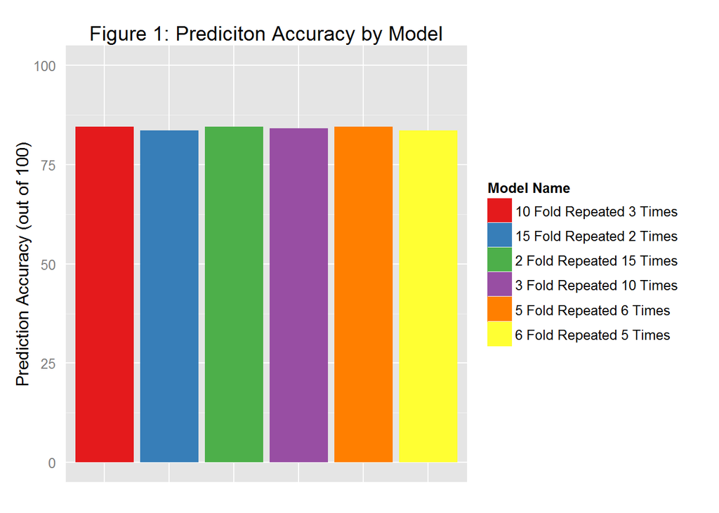

We observe that kappa ranges between 65 and 67 percent.

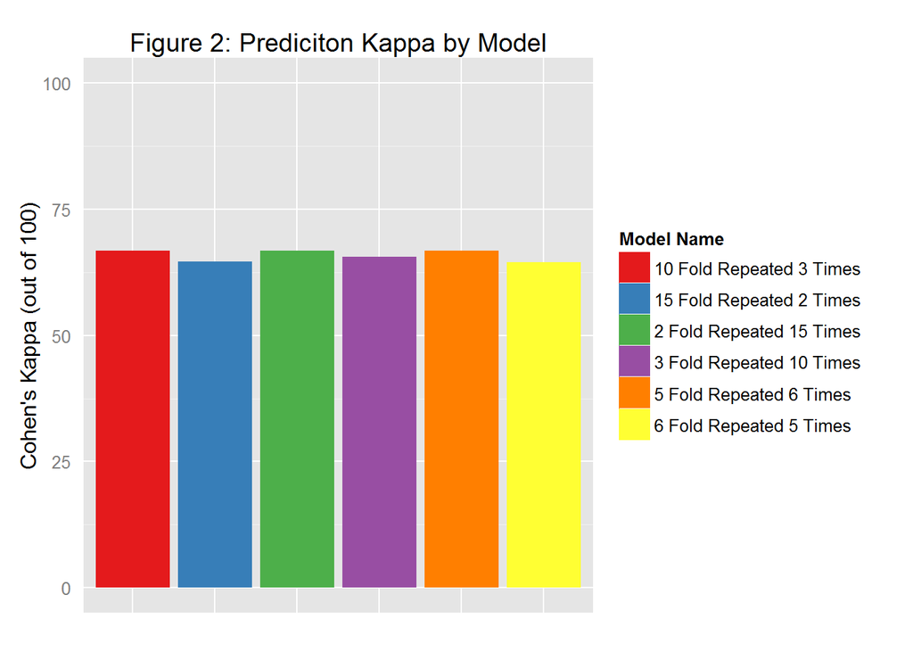

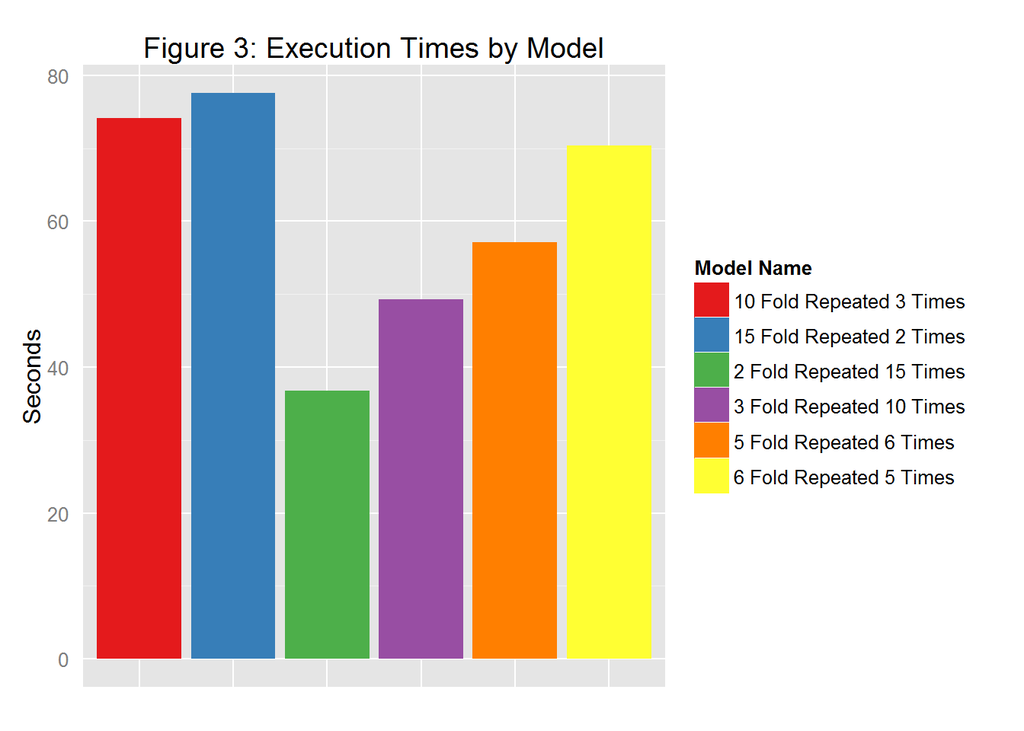

## The Accuracy / Execution Time Tradeoff

Now let’s construct a model prediction performance measure that averages the two preceeding accuracy measures and expresses it as a percentage:

```r
compare$performance <- ((compare$accuracy + compare$kappa)/2)*100
```

Let’s compare this performance measure relative to the execution time to observe the tradeoff between accuracy and execution time. We observe there is not much of a difference in the accuracy.

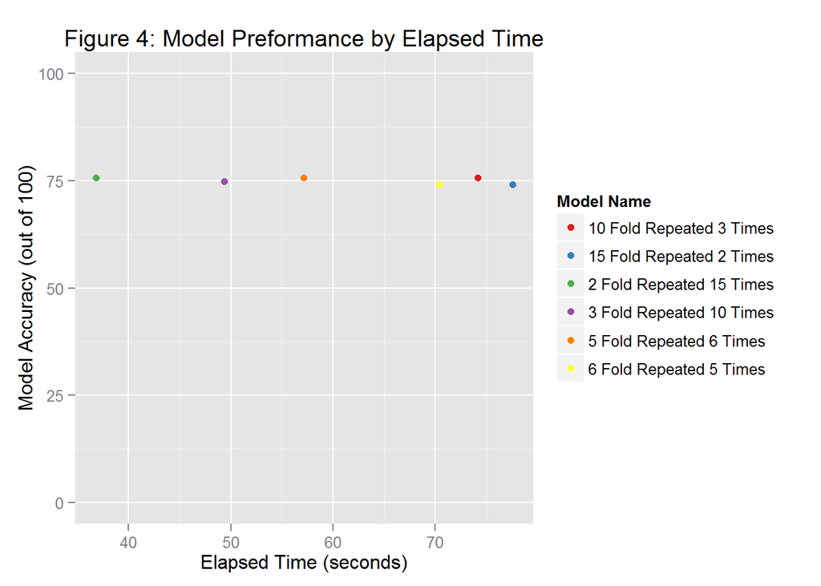

Execution time can very depending on the system the analysis is run on.

# Appendix

## Titanic Survivor Dataset

|  | pclass | survived | name | sex | age | sibsp | parch | ticket | fare | cabin | embarked | boat | body | home.dest |
| --- | --- | --- | --- | --- | --- | --- | --- | --- | --- | --- | --- | --- | --- | --- |
| 1 | 1 | Yes | Allen, Miss. Elisabeth Walton | female | 29 | 0 | 0 | 24160 | 211.3375 | B5 | S | 2 |  | St Louis, MO |
| 2 | 1 | Yes | Allison, Master. Hudson Trevor | male | 0.9167 | 1 | 2 | 113781 | 151.55 | C22 C26 | S | 11 |  | Montreal, PQ / Chesterville, ON |
| 3 | 1 | No | Allison, Miss. Helen Loraine | female | 2 | 1 | 2 | 113781 | 151.55 | C22 C26 | S |  |  | Montreal, PQ / Chesterville, ON |
| 4 | 1 | No | Allison, Mr. Hudson Joshua Creighton | male | 30 | 1 | 2 | 113781 | 151.55 | C22 C26 | S |  | 135 | Montreal, PQ / Chesterville, ON |
| 5 | 1 | No | Allison, Mrs. Hudson J C (Bessie Waldo Daniels) | female | 25 | 1 | 2 | 113781 | 151.55 | C22 C26 | S |  |  | Montreal, PQ / Chesterville, ON |
| 6 | 1 | Yes | Anderson, Mr. Harry | male | 48 | 0 | 0 | 19952 | 26.55 | E12 | S | 3 |  | New York, NY |
| 7 | 1 | Yes | Andrews, Miss. Kornelia Theodosia | female | 63 | 1 | 0 | 13502 | 77.9583 | D7 | S | 10 |  | Hudson, NY |
| 8 | 1 | No | Andrews, Mr. Thomas Jr | male | 39 | 0 | 0 | 112050 | 0 | A36 | S |  |  | Belfast, NI |
| 9 | 1 | Yes | Appleton, Mrs. Edward Dale (Charlotte Lamson) | female | 53 | 2 | 0 | 11769 | 51.4792 | C101 | S | D |  | Bayside, Queens, NY |
| 10 | 1 | No | Artagaveytia, Mr. Ramon | male | 71 | 0 | 0 | PC 17609 | 49.5042 |  | C |  | 22 | Montevideo, Uruguay |

[output cut: 1299 more lines]

## Model Comparison Statistics

|  | model.name | accuracy | kappa | elapsed | folds | repeats | performance |
| --- | --- | --- | --- | --- | --- | --- | --- |
| 1 | 10 Fold Repeated 3 Times | 0.8461538461538461 | 0.6671667166716672 | 74.13 | 10 | 3 | 75.66602814127566 |
| 2 | 2 Fold Repeated 15 Times | 0.8461538461538461 | 0.6671667166716672 | 36.8 | 3 | 10 | 75.66602814127566 |
| 3 | 3 Fold Repeated 10 Times | 0.8413461538461539 | 0.6561122244488978 | 49.34 | 5 | 6 | 74.87291891475259 |
| 4 | 5 Fold Repeated 6 Times | 0.8461538461538461 | 0.6671667166716672 | 57.14000000000001 | 6 | 5 | 75.66602814127566 |
| 5 | 6 Fold Repeated 5 Times | 0.8365384615384616 | 0.6450155606866781 | 70.40999999999997 | 15 | 2 | 74.07770111125697 |
| 6 | 15 Fold Repeated 2 Times | 0.8365384615384616 | 0.6463646364636465 | 77.56 | 2 | 15 | 74.14515490010541 |

## Machine Learning Models

```r
model1
```

```
Random Forest

835 samples
  7 predictor
  2 classes: 'No', 'Yes'

No pre-processing
Resampling: Cross-Validated (10 fold, repeated 3 times)

Summary of sample sizes: 752, 752, 751, 752, 752, 752, ...

Resampling results across tuning parameters:

  mtry  Accuracy   Kappa      Accuracy SD  Kappa SD
  2     0.7928428  0.5515118  0.04539346   0.10349071
  5     0.7820759  0.5378130  0.04245491   0.09206266
  8     0.7796376  0.5368102  0.04512580   0.09657816

Accuracy was used to select the optimal model using  the largest value.
The final value used for the model was mtry = 2.
```

```r
model2
```

```
Random Forest

835 samples
  7 predictor
  2 classes: 'No', 'Yes'

No pre-processing
Resampling: Cross-Validated (2 fold, repeated 15 times)

Summary of sample sizes: 418, 417, 417, 418, 418, 417, ...

Resampling results across tuning parameters:

  mtry  Accuracy   Kappa      Accuracy SD  Kappa SD
  2     0.7793195  0.5286911  0.01522927   0.03121892
  5     0.7696589  0.5154423  0.01304574   0.02622820
  8     0.7629554  0.5032903  0.01497287   0.03144805

Accuracy was used to select the optimal model using  the largest value.
The final value used for the model was mtry = 2.
```

```r
model3
```

```
Random Forest

835 samples
  7 predictor
  2 classes: 'No', 'Yes'

No pre-processing
Resampling: Cross-Validated (3 fold, repeated 10 times)

Summary of sample sizes: 556, 557, 557, 557, 556, 557, ...

Resampling results across tuning parameters:

  mtry  Accuracy   Kappa      Accuracy SD  Kappa SD
  2     0.7916295  0.5526894  0.02091732   0.04549287
  5     0.7800151  0.5351898  0.02131784   0.04697187
  8     0.7682748  0.5128827  0.02253686   0.04884840

Accuracy was used to select the optimal model using  the largest value.
The final value used for the model was mtry = 2.
```

```r
model4
```

```
Random Forest

835 samples
  7 predictor
  2 classes: 'No', 'Yes'

No pre-processing
Resampling: Cross-Validated (5 fold, repeated 6 times)

Summary of sample sizes: 668, 668, 668, 668, 668, 668, ...

Resampling results across tuning parameters:

  mtry  Accuracy   Kappa      Accuracy SD  Kappa SD
  2     0.7930140  0.5535618  0.03400756   0.07496490
  5     0.7780439  0.5319503  0.03519569   0.07612576
  8     0.7688623  0.5155179  0.03067849   0.06515326

Accuracy was used to select the optimal model using  the largest value.
The final value used for the model was mtry = 2.
```

```r
model5
```

```
Random Forest

835 samples
  7 predictor
  2 classes: 'No', 'Yes'

No pre-processing
Resampling: Cross-Validated (6 fold, repeated 5 times)

Summary of sample sizes: 696, 697, 696, 696, 695, 695, ...

Resampling results across tuning parameters:

  mtry  Accuracy   Kappa      Accuracy SD  Kappa SD
  2     0.7933613  0.5552966  0.02947309   0.06495364
  5     0.7770934  0.5294277  0.03324196   0.07055347
  8     0.7689310  0.5148858  0.03463606   0.07326009

Accuracy was used to select the optimal model using  the largest value.
The final value used for the model was mtry = 2.
```

```r
model6
```

```
Random Forest

835 samples
  7 predictor
  2 classes: 'No', 'Yes'

No pre-processing
Resampling: Cross-Validated (15 fold, repeated 2 times)

Summary of sample sizes: 780, 780, 779, 780, 779, 780, ...

Resampling results across tuning parameters:

  mtry  Accuracy   Kappa      Accuracy SD  Kappa SD
  2     0.7885281  0.5440804  0.05989008   0.1351930
  5     0.7825000  0.5395214  0.06138424   0.1344344
  8     0.7734740  0.5234291  0.06355332   0.1374453

Accuracy was used to select the optimal model using  the largest value.
The final value used for the model was mtry = 2.
```